# DMA - Homework #1

Viet Ba Mai

10 października 2016

# Description

In this homework we used the PogromcyDanych package along with its function setLang() which translates a dataset between English and Polish depending and the given parameter. The goal was to create summaries, both numerical and graphical, for the dataset skiJumps2013 which represent real data from ski jumping competitions held in 2013 and 2014. The summaries were done on the following variables:

- jumpSpeed
- jumpDistance
- compCountry
- jumperCountry
- jumperDateOfBirth.

This report is done only on data where the competition was in 2014.

10 observations of selected columns from the skiJumps2013 table (with a date filter applied on) are presented below.

```
##       compDate jumpSpeed jumpDistance compCountry jumperCountry
## 690 2014-01-01      93.4        132.5     Germany           FIN
## 691 2014-01-01      93.8        132.5     Germany           FIN
## 692 2014-01-01      93.2        139.0     Germany           SUI
## 693 2014-01-01      93.4        133.5     Germany           SUI
## 694 2014-01-01      93.3        129.0     Germany           NOR
## 695 2014-01-01      92.8        134.5     Germany           NOR
## 696 2014-01-01      93.0        128.0     Germany           POL
## 697 2014-01-01      92.5         26.0     Germany           POL
## 698 2014-01-01      92.1        133.0     Germany           SLO
## 699 2014-01-01      92.4        131.0     Germany           SLO
##     jumperDateOfBirth
## 690        1977-05-11
## 691        1977-05-11
## 692        1981-06-25
## 693        1981-06-25
## 694        1982-08-24
## 695        1982-08-24
## 696        1994-05-21
## 697        1994-05-21
## 698        1983-05-28
## 699        1983-05-28
```

# Numerical Summaries

## Categorical Variables

For categorical values we use contingency tables. This is done by using the table() function.

1. Competition Country:

```
##
##  Austria  Germany  Finland    Japan   Norway Slovenia   Poland   Sweden
##      268      241      239      163      160      159      130       81
```

2. Jumper’s Country:

```
##
## AUT SLO GER POL NOR CZE JPN FIN SUI RUS ITA FRA EST CAN USA BUL ROU GRE
## 226 201 198 158 153 131 115  79  54  42  25  19  14  12   4   3   3   2
## KOR
##   2
```

3. Jumper’s Date Of Birth:

```
##
## 1992-09-20 1993-05-13 1980-01-29 1987-05-25 1991-03-05 1972-06-06
##         35         35         32         32         32         31
## 1983-05-28 1988-05-11 1979-01-15 1984-05-17 1989-02-14 1990-01-07
##         31         31         30         29         28         28
## 1991-02-13 1991-06-09 1992-02-25
##         28         28         28
##  [ reached getOption("max.print") -- omitted 101 entries ]
```

The number of output was limited to 15.

## Continuous Variables

For continuous values we use the summary() function.

1. Jump Speed:

```
##    Min. 1st Qu.  Median    Mean 3rd Qu.    Max.
##    0.00   89.80   90.70   91.98   93.60  101.50
```

2. Jump Distance:

```
##    Min. 1st Qu.  Median    Mean 3rd Qu.    Max.
##     0.0   119.5   126.0   127.5   132.5   199.0
```

# Graphical Summaries

## Categorical Variables

Barplots [barplot()] are very well suited to visualize contingency tables.

1. Competition Country:

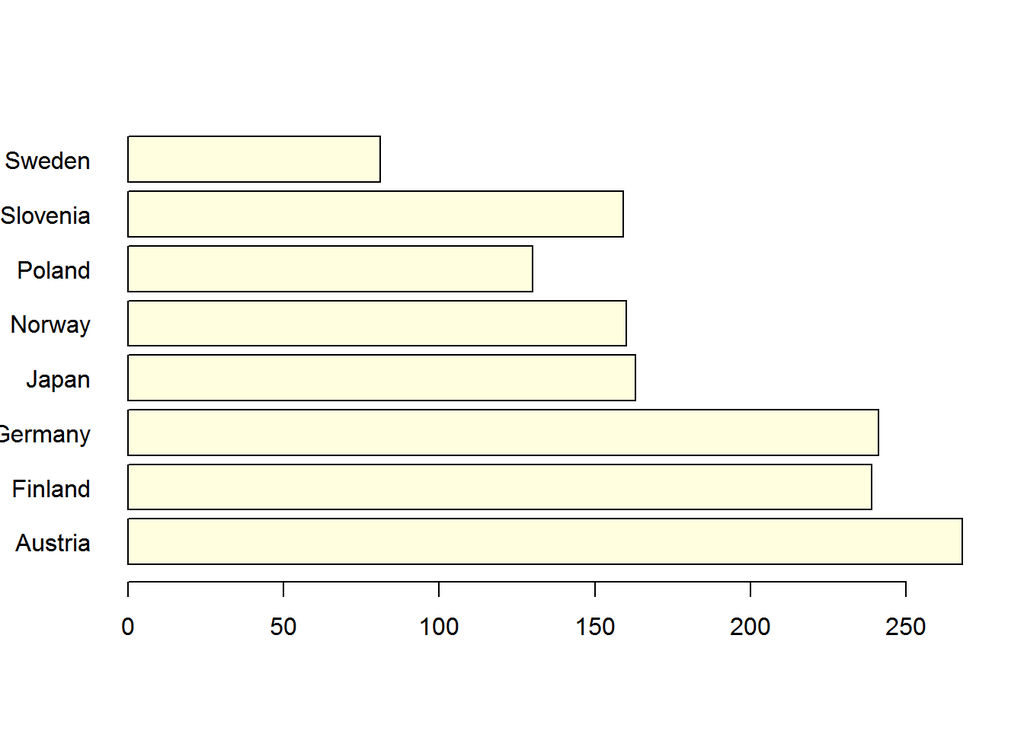

2. Jumper’s Country:

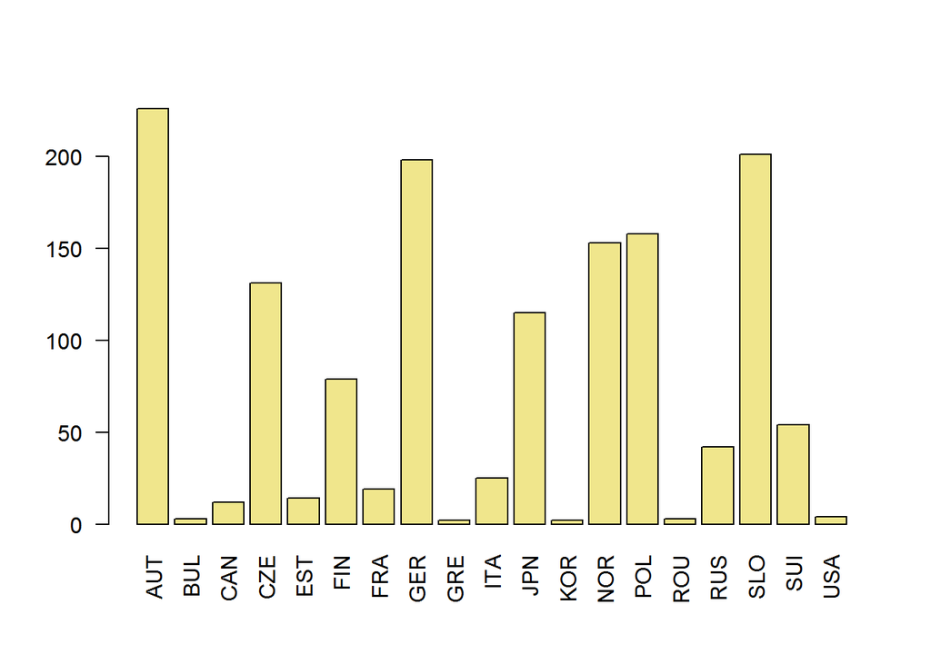

3. Jumper’s Year Of Birth:

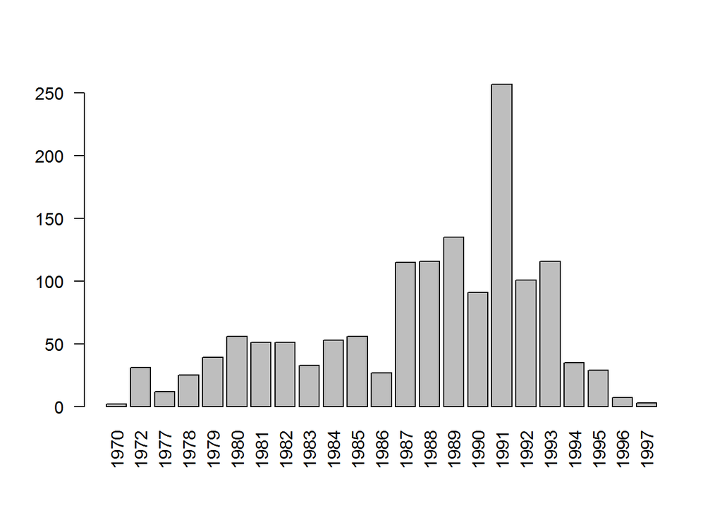

Years were extracted from full dates to make the graph clearer.

## Continuous Variables

Histograms [hist()] and boxplots [boxplot()] can be used to represent the distribution of continuous values.

1. Jump Speed:

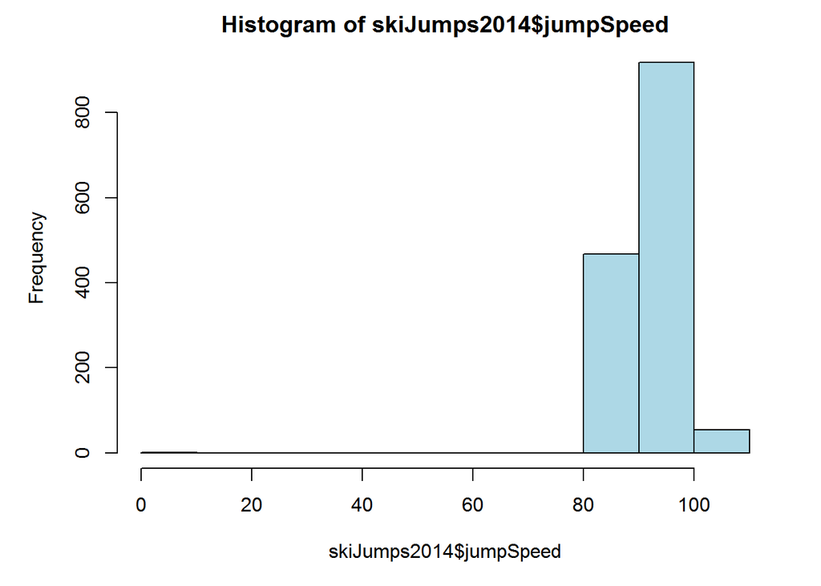

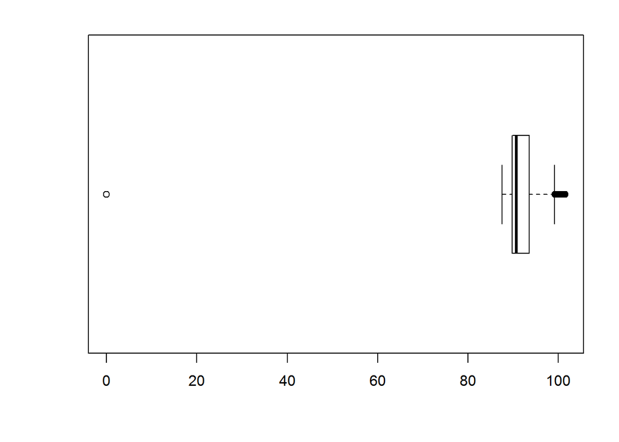

2. Jump Distance:

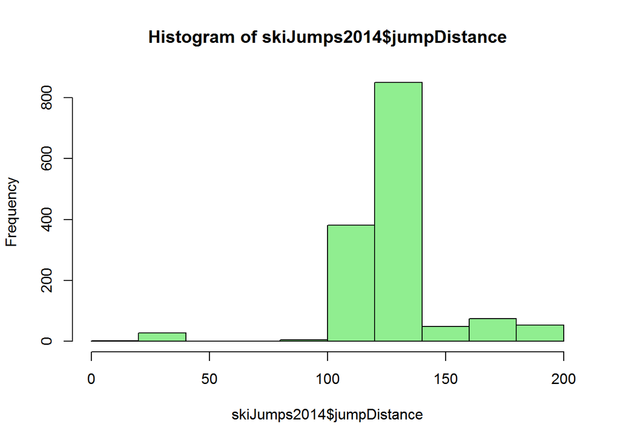

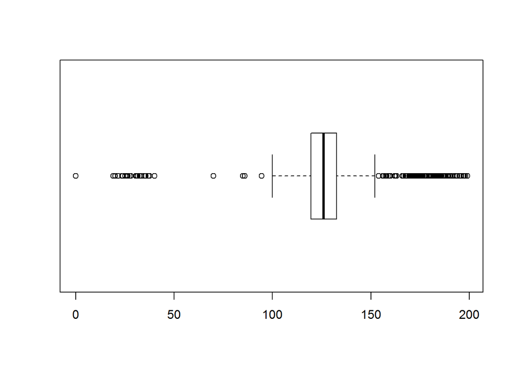

# 2-variable representations

## Numerical Summaries for different discrete variables

1. Jump Speed by Jumper Country:

```
## skiJumps2014$jumperCountry: AUT
##    Min. 1st Qu.  Median    Mean 3rd Qu.    Max.
##    0.00   90.00   90.85   91.99   93.90  101.30
## --------------------------------------------------------
## skiJumps2014$jumperCountry: BUL
##    Min. 1st Qu.  Median    Mean 3rd Qu.    Max.
##   88.80   88.80   88.80   89.30   89.55   90.30
## --------------------------------------------------------
## skiJumps2014$jumperCountry: CAN
##    Min. 1st Qu.  Median    Mean 3rd Qu.    Max.
##   89.10   90.15   90.55   93.22   96.50  100.50
## --------------------------------------------------------
## skiJumps2014$jumperCountry: CZE
##    Min. 1st Qu.  Median    Mean 3rd Qu.    Max.
##    87.8    89.6    90.3    92.0    93.7   100.4
## --------------------------------------------------------
## skiJumps2014$jumperCountry: EST
##    Min. 1st Qu.  Median    Mean 3rd Qu.    Max.
##   89.10   90.22   90.35   91.30   91.85   95.80
## --------------------------------------------------------
## skiJumps2014$jumperCountry: FIN
##    Min. 1st Qu.  Median    Mean 3rd Qu.    Max.
##   87.60   89.75   90.50   91.39   92.90  100.10
## --------------------------------------------------------
## skiJumps2014$jumperCountry: FRA
##    Min. 1st Qu.  Median    Mean 3rd Qu.    Max.
##   88.60   89.65   90.10   90.89   91.75   95.60
## --------------------------------------------------------
## skiJumps2014$jumperCountry: GER
##    Min. 1st Qu.  Median    Mean 3rd Qu.    Max.
##   87.90   90.00   91.00   92.24   93.60  101.50
## --------------------------------------------------------
## skiJumps2014$jumperCountry: GRE
##    Min. 1st Qu.  Median    Mean 3rd Qu.    Max.
##   89.20   89.52   89.85   89.85   90.18   90.50
## --------------------------------------------------------
## skiJumps2014$jumperCountry: ITA
##    Min. 1st Qu.  Median    Mean 3rd Qu.    Max.
##   88.50   89.40   90.10   91.23   93.80   97.10
## --------------------------------------------------------
```

[output cut: 20 more lines]

```
## skiJumps2014$jumperCountry: RUS
##    Min. 1st Qu.  Median    Mean 3rd Qu.    Max.
##   88.60   89.43   90.35   91.04   92.30   95.90
## --------------------------------------------------------
## skiJumps2014$jumperCountry: SLO
##    Min. 1st Qu.  Median    Mean 3rd Qu.    Max.
##   87.50   89.90   91.10   92.35   94.30  100.90
## --------------------------------------------------------
## skiJumps2014$jumperCountry: SUI
##    Min. 1st Qu.  Median    Mean 3rd Qu.    Max.
##   88.50   89.75   91.65   92.39   93.55  100.80
## --------------------------------------------------------
## skiJumps2014$jumperCountry: USA
##    Min. 1st Qu.  Median    Mean 3rd Qu.    Max.
##   89.50   89.65   90.20   91.98   92.52   98.00
```

2. Jump Distance by Jumper Country:

```
## skiJumps2014$jumperCountry: AUT
##    Min. 1st Qu.  Median    Mean 3rd Qu.    Max.
##     0.0   123.0   127.0   129.1   133.0   197.5
## --------------------------------------------------------
## skiJumps2014$jumperCountry: BUL
##    Min. 1st Qu.  Median    Mean 3rd Qu.    Max.
##   105.5   110.0   114.5   113.2   117.0   119.5
## --------------------------------------------------------
## skiJumps2014$jumperCountry: CAN
##    Min. 1st Qu.  Median    Mean 3rd Qu.    Max.
##   109.5   117.9   119.5   131.8   135.1   181.5
## --------------------------------------------------------
## skiJumps2014$jumperCountry: CZE
##    Min. 1st Qu.  Median    Mean 3rd Qu.    Max.
##    19.0   118.0   124.0   126.3   130.8   186.5
## --------------------------------------------------------
## skiJumps2014$jumperCountry: EST
##    Min. 1st Qu.  Median    Mean 3rd Qu.    Max.
##   110.0   115.8   121.0   121.9   128.4   133.5
## --------------------------------------------------------
## skiJumps2014$jumperCountry: FIN
##    Min. 1st Qu.  Median    Mean 3rd Qu.    Max.
##    31.0   118.2   124.0   123.4   129.5   173.5
## --------------------------------------------------------
## skiJumps2014$jumperCountry: FRA
##    Min. 1st Qu.  Median    Mean 3rd Qu.    Max.
##   109.0   115.0   120.5   119.3   122.8   134.5
## --------------------------------------------------------
## skiJumps2014$jumperCountry: GER
##    Min. 1st Qu.  Median    Mean 3rd Qu.    Max.
##    23.5   120.0   127.0   128.4   133.5   190.0
## --------------------------------------------------------
## skiJumps2014$jumperCountry: GRE
##    Min. 1st Qu.  Median    Mean 3rd Qu.    Max.
##   113.5   116.0   118.5   118.5   121.0   123.5
## --------------------------------------------------------
## skiJumps2014$jumperCountry: ITA
##    Min. 1st Qu.  Median    Mean 3rd Qu.    Max.
##   111.0   114.0   119.0   121.5   124.5   172.0
## --------------------------------------------------------
```

[output cut: 20 more lines]

```
## skiJumps2014$jumperCountry: RUS
##    Min. 1st Qu.  Median    Mean 3rd Qu.    Max.
##   102.0   112.0   120.8   119.8   126.9   142.5
## --------------------------------------------------------
## skiJumps2014$jumperCountry: SLO
##    Min. 1st Qu.  Median    Mean 3rd Qu.    Max.
##    21.5   121.0   128.0   130.5   134.0   199.0
## --------------------------------------------------------
## skiJumps2014$jumperCountry: SUI
##    Min. 1st Qu.  Median    Mean 3rd Qu.    Max.
##    37.0   120.8   126.8   131.8   133.5   195.0
## --------------------------------------------------------
## skiJumps2014$jumperCountry: USA
##    Min. 1st Qu.  Median    Mean 3rd Qu.    Max.
##   109.5   112.9   115.2   124.4   126.8   157.5
```

## Graphical summary for two discrete variables

Mosaicplots may be useful to show relations between different categorical variables.

Competition Country and Jumper Country:

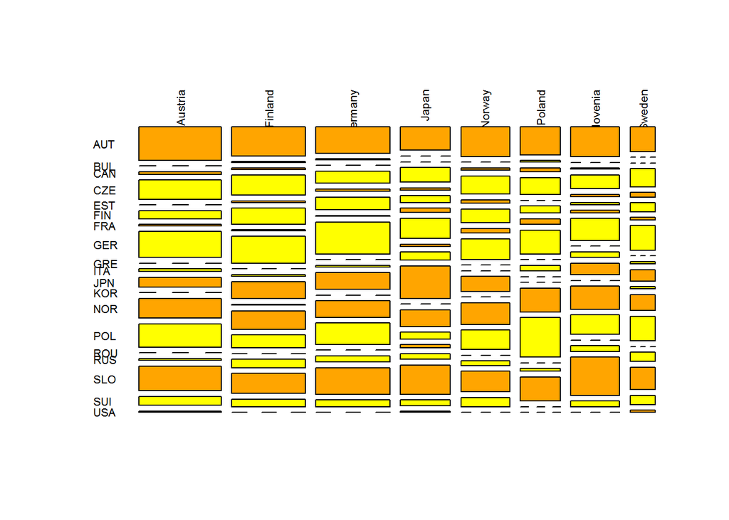

## Numerical summary of relation between discrete and continuous variables.

Jumper Country and Jump Distance:

[output not shown]

The number of output was limited to 25.

## Graphical summary of continuous variables.

Again, boxplots are very good for this type of variables. Additionally, a more advanced way is to use vioplot [vioplot()].

Jump Distance and Jump Speed:

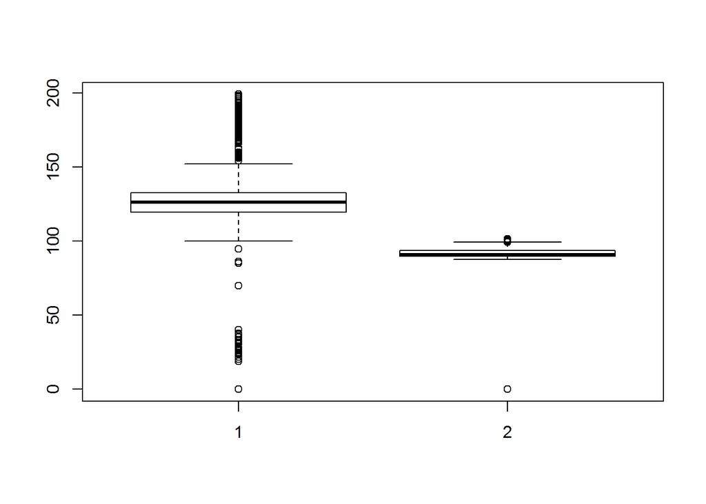

# Conclusions

Most of the competitors were born in 1991 and the second most frequent birth year is 1989 with the frequency being almost only a half of the aforementioned year.

In terms of the jump itself, the usual speed is around 80 to 100 while the distance is between 100 and 150.

Germany has the highest maximum jumping speed (101.50) while Slovenia has the highest maximum jumping distance (199.0). On the other hand Romania has the lowest mean jumping speed (88.97) and Japan has the lowest mean in jumping distance (112.0).